# Haben die Menschen mehr oder weniger an Orten auf?

Wir untersuchen, ob die Einschränkungen des öffentlichen Lebens ("social distancing") Leute dazu veranlasst, sich an bestimmten Orten mehr oder weniger aufzuhalten als üblich.

**Datensatz**

Gescrapte Daten von der Google Places API.

Als Indikatoren gibt es `current_popularity` und `usual_popularity`, beides von Google errechnete Werte, die den aktuellen bzw. in der Vergangenheit durchschnittlichen Besucherstrom an einem Ort angibt.

Mit einem *score* `current_popularity` / `usual_popularity` lässt sich beschreiben, wie sich die aktuelle "Popularität" gegenüber der zum gleichen Zeitpunkt durchschnittlichen verhält.

Ist dieser score bspw. 0.5, halten sich gerade nur halb so viele Leute auf wie normalerweise. Ist er > 1, sind dort mehr als üblich.

Die Daten wurden vergangene Woche, teilweise erst dieses Wochenende gescraped.

Es wird immer angegeben, wie viele Datenpunkte (gescraped wurde 1 mal pro Stunde) vorhanden sind und aus welchem Zeitraum.

```python
%matplotlib inline
from runpandarun.datasets import googleplaces

df = googleplaces['cleaned']

# helper method
def aggregate(df, columns):
    # aggregate by "columns"
    df_g = df.reset_index().groupby(columns).agg({
        'ts': ['min', 'max'],       # Zeitraum, für den Messdaten vorliegen
        'id': 'count',              # Anzahl der einzelnen Messwerte
        'popularity_score': 'mean'  # wir benutzen arithmetisches Mittel, s. Erläuterung unten
    })
    df_g['popularity_diff'] = (df_g[('popularity_score', 'mean')] - 1) * 100   # prozentuale Veränderung
    return df_g
```

[output not shown]

[output not shown]

## Durchschnittliche Veränderung pro Kategorie

```python
df_data = aggregate(df, 'type')
df_data.sort_values('popularity_diff')
```

[output not shown]

```python
googleplaces.publish(df_data, name='googleplaces-aggregiert_total', overwrite=True)
```

```
'https://norddeutscherrundfunk.github.io/googleplaces/googleplaces-aggregiert_total.csv'
```

## Durchschnittliche Veränderung pro Bundesland

Die Balken zeigen, ausgehend vom rechten Rand (üblicher durchschnittlicher Besuchswert) den durchschnittlichen Rückgang. Je länger der Balken nach links geht, desto weniger waren die üblichen Orte dieses Wochenende besucht.

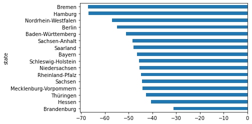

```python
df_data = aggregate(df, 'state')
df_data.sort_values('popularity_diff', ascending=False)['popularity_diff'].plot.barh()
```

```python
df_data.sort_values('popularity_diff')
```

[output not shown]

```python
googleplaces.publish(df_data, name='googleplaces-aggregiert_bundeslaender', overwrite=True)
```

```
'https://norddeutscherrundfunk.github.io/googleplaces/googleplaces-aggregiert_bundeslaender.csv'
```

## Durchschnittliche Veränderung pro Bundesland & Typ

```python
df_data = aggregate(df, ['state', 'type'])
df_data
```

| state | type | ts min | ts max | id count | popularity_score mean | popularity_diff |
| --- | --- | --- | --- | --- | --- | --- |
| Baden-Württemberg | shopping_mall | 2020-03-27 15:00:00 | 2020-03-29 19:00:00 | 242 | 0.573819 | -42.618080 |
|  | supermarket | 2020-03-27 15:00:00 | 2020-03-28 19:00:00 | 1150 | 0.617644 | -38.235632 |
|  | transit_station | 2020-03-22 12:00:00 | 2020-03-29 19:00:00 | 2067 | 0.410247 | -58.975257 |
| Bayern | park | 2020-03-28 10:00:00 | 2020-03-29 15:00:00 | 17 | 1.054582 | 5.458172 |
|  | shopping_mall | 2020-03-28 10:00:00 | 2020-03-29 18:00:00 | 278 | 0.429013 | -57.098734 |
|  | supermarket | 2020-03-27 15:00:00 | 2020-03-28 18:00:00 | 2866 | 0.621570 | -37.842995 |
|  | transit_station | 2020-03-22 12:00:00 | 2020-03-29 19:00:00 | 942 | 0.293897 | -70.610269 |
| Berlin | park | 2020-03-28 10:00:00 | 2020-03-29 19:00:00 | 142 | 1.333123 | 33.312258 |
|  | transit_station | 2020-03-22 12:00:00 | 2020-03-29 19:00:00 | 576 | 0.238785 | -76.121522 |
| Brandenburg | shopping_mall | 2020-03-28 10:00:00 | 2020-03-28 18:00:00 | 54 | 0.306893 | -69.310651 |
|  | supermarket | 2020-03-27 15:00:00 | 2020-03-28 19:00:00 | 670 | 0.722428 | -27.757160 |
|  | transit_station | 2020-03-22 12:00:00 | 2020-03-29 19:00:00 | 138 | 0.673036 | -32.696417 |
| Bremen | transit_station | 2020-03-22 12:00:00 | 2020-03-29 19:00:00 | 172 | 0.328929 | -67.107103 |
| Hamburg | park | 2020-03-28 10:00:00 | 2020-03-29 19:00:00 | 21 | 1.703901 | 70.390147 |
|  | transit_station | 2020-03-22 12:00:00 | 2020-03-29 19:00:00 | 1103 | 0.306313 | -69.368696 |
| Hessen | park | 2020-03-28 10:00:00 | 2020-03-29 19:00:00 | 42 | 2.633889 | 163.388851 |
|  | shopping_mall | 2020-03-28 10:00:00 | 2020-03-29 19:00:00 | 169 | 0.290233 | -70.976657 |
|  | supermarket | 2020-03-27 15:00:00 | 2020-03-28 19:00:00 | 1024 | 0.655983 | -34.401745 |
|  | transit_station | 2020-03-22 12:00:00 | 2020-03-29 19:00:00 | 710 | 0.455092 | -54.490769 |
| Mecklenburg-Vorpommern | shopping_mall | 2020-03-28 10:00:00 | 2020-03-29 09:00:00 | 26 | 0.749482 | -25.051842 |
|  | supermarket | 2020-03-27 15:00:00 | 2020-03-28 19:00:00 | 226 | 0.699565 | -30.043513 |
|  | transit_station | 2020-03-22 12:00:00 | 2020-03-29 19:00:00 | 515 | 0.487783 | -51.221721 |
| Niedersachsen | shopping_mall | 2020-03-27 15:00:00 | 2020-03-29 19:00:00 | 252 | 0.338041 | -66.195855 |
|  | supermarket | 2020-03-27 15:00:00 | 2020-03-28 19:00:00 | 1707 | 0.632256 | -36.774441 |
|  | transit_station | 2020-03-22 12:00:00 | 2020-03-29 19:00:00 | 760 | 0.421478 | -57.852211 |
| Nordrhein-Westfalen | park | 2020-03-28 10:00:00 | 2020-03-29 19:00:00 | 41 | 2.364475 | 136.447455 |
|  | shopping_mall | 2020-03-28 10:00:00 | 2020-03-29 15:00:00 | 213 | 0.425639 | -57.436137 |
|  | supermarket | 2020-03-27 15:00:00 | 2020-03-28 19:00:00 | 1269 | 0.681848 | -31.815171 |
|  | transit_station | 2020-03-22 12:00:00 | 2020-03-29 19:00:00 | 8338 | 0.382294 | -61.770592 |
| Rheinland-Pfalz | shopping_mall | 2020-03-28 10:00:00 | 2020-03-29 19:00:00 | 102 | 0.477537 | -52.246306 |
|  | supermarket | 2020-03-27 15:00:00 | 2020-03-28 19:00:00 | 1197 | 0.649246 | -35.075380 |
|  | transit_station | 2020-03-22 12:00:00 | 2020-03-29 19:00:00 | 790 | 0.412376 | -58.762423 |
| Saarland | shopping_mall | 2020-03-27 15:00:00 | 2020-03-28 18:00:00 | 39 | 0.256504 | -74.349645 |
|  | supermarket | 2020-03-27 15:00:00 | 2020-03-28 18:00:00 | 235 | 0.623598 | -37.640237 |
|  | transit_station | 2020-03-27 15:00:00 | 2020-03-29 19:00:00 | 56 | 0.278791 | -72.120943 |
| Sachsen | park | 2020-03-28 10:00:00 | 2020-03-29 19:00:00 | 41 | 1.906680 | 90.668047 |
|  | shopping_mall | 2020-03-28 10:00:00 | 2020-03-28 18:00:00 | 45 | 0.270236 | -72.976357 |
|  | supermarket | 2020-03-27 15:00:00 | 2020-03-28 19:00:00 | 345 | 0.672860 | -32.714042 |
|  | transit_station | 2020-03-22 12:00:00 | 2020-03-29 19:00:00 | 651 | 0.427089 | -57.291052 |
| Sachsen-Anhalt | shopping_mall | 2020-03-27 15:00:00 | 2020-03-28 17:00:00 | 55 | 0.373132 | -62.686804 |
|  | supermarket | 2020-03-27 15:00:00 | 2020-03-28 18:00:00 | 557 | 0.637264 | -36.273633 |
|  | transit_station | 2020-03-22 12:00:00 | 2020-03-29 19:00:00 | 351 | 0.345384 | -65.461590 |
| Schleswig-Holstein | shopping_mall | 2020-03-27 15:00:00 | 2020-03-28 19:00:00 | 109 | 0.388109 | -61.189150 |
|  | supermarket | 2020-03-27 15:00:00 | 2020-03-28 19:00:00 | 638 | 0.657578 | -34.242198 |
|  | transit_station | 2020-03-22 12:00:00 | 2020-03-29 19:00:00 | 293 | 0.354539 | -64.546052 |
| Thüringen | shopping_mall | 2020-03-27 15:00:00 | 2020-03-29 15:00:00 | 141 | 0.427271 | -57.272939 |
|  | supermarket | 2020-03-27 15:00:00 | 2020-03-28 18:00:00 | 874 | 0.658857 | -34.114284 |
|  | transit_station | 2020-03-22 12:00:00 | 2020-03-29 19:00:00 | 509 | 0.469428 | -53.057156 |

```python
googleplaces.publish(df_data, name='googleplaces-aggregiert_bundeslaender_typen', overwrite=True)
```

```
'https://norddeutscherrundfunk.github.io/googleplaces/googleplaces-aggregiert_bundeslaender_typen.csv'
```

## Ursprungsdaten

zum Nachvollziehen...

```python
df.head()
```

| ts | id | name | types | lat | lng | current_popularity | usual_popularity | ags | city | state | type | popularity_score |
| --- | --- | --- | --- | --- | --- | --- | --- | --- | --- | --- | --- | --- |
| 2020-03-29 11:00:00 | ChIJo5QBjMS6uUcRKsDT3yQbqLQ | Königspassage | [shopping_mall, point_of_interest, establishment] | 51.959362 | 7.626496 | 3 | 7 | 05515 | Münster | Nordrhein-Westfalen | shopping_mall | 0.428571 |
| 2020-03-29 11:00:00 | ChIJtQTbBb9ypEcR07beOvd3rGI | Forum 1 | [shopping_mall, point_of_interest, establishment] | 50.974219 | 11.033275 | 7 | 19 | 16051 | Erfurt | Thüringen | shopping_mall | 0.368421 |
| 2020-03-29 11:00:00 | ChIJF_5ayFFCtkcR727QKf_wcbQ | Caro | [shopping_mall, point_of_interest, establishment] | 53.467054 | 7.482232 | 5 | 6 | 03452 | Aurich | Niedersachsen | shopping_mall | 0.833333 |
| 2020-03-29 11:00:00 | ChIJO4uLamNwvUcRGRruh5X2cxc | Luisencenter Darmstadt | [shopping_mall, point_of_interest, establishment] | 49.871842 | 8.651633 | 2 | 0 | 06411 | Darmstadt | Hessen | shopping_mall | NaN |
| 2020-03-29 11:00:00 | ChIJPQHojUEvmEcRRCeh_VQUzjY | Shoppinghaus | [shopping_mall, point_of_interest, establishment] | 49.143680 | 9.223536 | 9 | 2 | 08121 | Heilbronn | Baden-Württemberg | shopping_mall | 4.500000 |

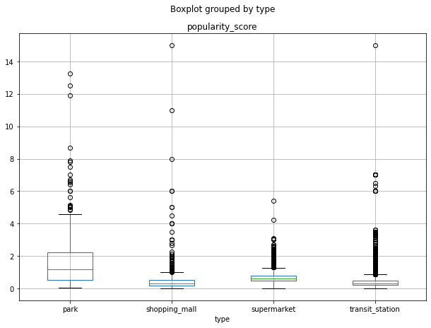

```python
df.boxplot('popularity_score', 'type', figsize=(10, 7))
```